# Exploratory analysis of penalties

# Data description

Where the data is from? What are the observations (note there can be several types – players, plays, penalties), and how many of them? What’s the time period covered? What’s the geography covered? Is there missing data?

## Number of Observations

```r
nrow(players)
```

```
[1] 3925
```

```r
nrow(penalties)
```

```
[1] 247828
```

```r
nrow(player_plays)
```

```
[1] 247733
```

Since the penalties dataset has more observations than players, this shows that there are players who have committed more than one penalty.

## Example 1: heights

An example of plotting height:

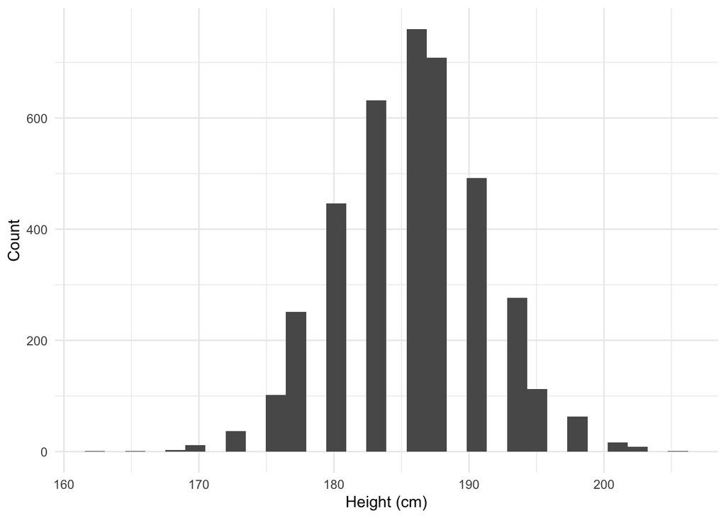

```r
ggplot(data = players, aes(x = height_cm)) +
  geom_histogram() +
  theme_minimal() +
  labs(x="Height (cm)", y = "Count")
```

Looks weird. What is there space between bars?

```r
players %>%
  count(height_cm)
```

```
   height_cm   n
1     162.56   1
2     165.10   1
3     167.64   3
4     170.18  12
5     172.72  37
6     175.26 102
7     177.80 251
8     180.34 446
9     182.88 632
10    185.42 760
11    187.96 708
12    190.50 492
13    193.04 276
14    195.58 112
15    198.12  63
16    200.66  16
17    203.20   9
18    205.74   1
19        NA   3
```

It looks like height is ordered categorical variable, not a continuous one. Weird!

## Example 2: national origins of players

48% come from Canada, more than from the US. Interesting! I wonder if nationality can predict penalties.

```r
players %>%
  count(nationality) %>%
  mutate(pct = round(n / sum(n),2)) %>%
  arrange(-n)
```

```
   nationality    n  pct
1          CAN 1896 0.48
2          USA  907 0.23
3          SWE  280 0.07
4          RUS  210 0.05
5          CZE  201 0.05
6          FIN  184 0.05
7          SVK   76 0.02
8          CHE   39 0.01
9          DEU   31 0.01
10         LVA   20 0.01
11         DNK   15 0.00
12         BLR    9 0.00
13         FRA    8 0.00
14        <NA>    8 0.00
15         AUT    7 0.00
16         NOR    7 0.00
17         UKR    6 0.00
18         GBR    4 0.00
19         KAZ    4 0.00
20         LTU    2 0.00
21         POL    2 0.00
22         SVN    2 0.00
23         AUS    1 0.00
24         BHS    1 0.00
25         HRV    1 0.00
26         ITA    1 0.00
27         JPN    1 0.00
28         NGA    1 0.00
29         NLD    1 0.00
```

## primary position

Are players that play certain positions more prone to causing penalties?

```r
players %>%
  count(primaryPosition)
```

```
  primaryPosition    n
1               C  932
2               D 1208
3               G  434
4              LW  709
5              RW  642
```

## Dominant Hand

Do right-handed players have more penalties than left-handed players?

```r
players %>%
  count(shootsCatches)
```

```
  shootsCatches    n
1             L 2594
2             R 1314
3          <NA>   17
```

More lefties than righties is interesting.

## Types of Penalties

```r
penalties %>%
  count(penaltySeverity)
```

```
  penaltySeverity      n
1     Bench Minor   3156
2 Game Misconduct    685
3           Major   8984
4           Match     84
5           Minor 104540
6      Misconduct   2299
7    Penalty Shot    551
8            <NA> 127529
```

## Penalty Minutes

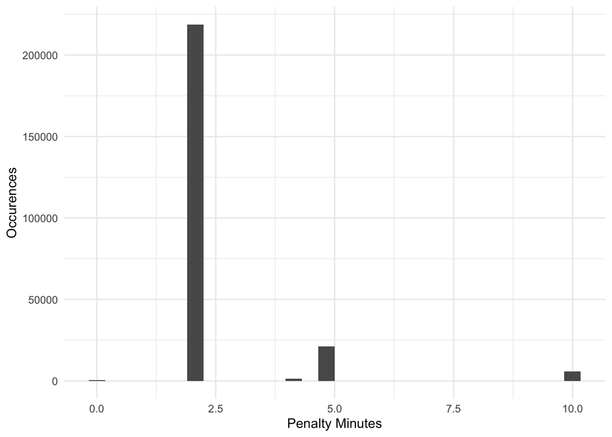

```r
ggplot(data = penalties, aes(x = penaltyMinutes)) +
  geom_histogram() +
  theme_minimal() +
  labs(x="Penalty Minutes", y = "Occurences")
```

A large majority of the penalties only had two minute punishments, while there are few occurrences of 5 and 10 minute penalties. Could this show deterrence? Are players who get a 10 minute penalty unlikely to commit penalties in the future? Could look at the timeline of this.

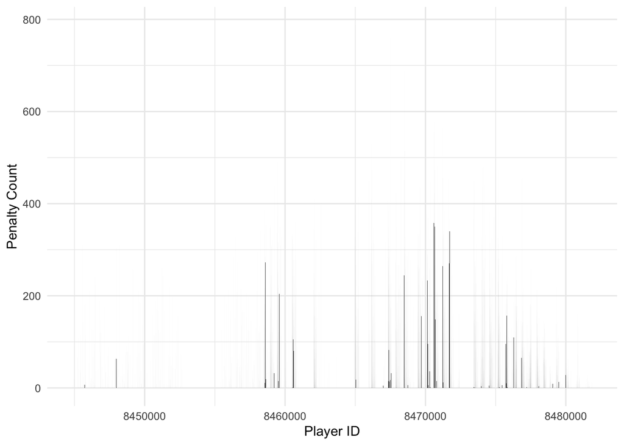

```r
ggplot(data = player_plays, aes(x = player_id)) +
  geom_histogram(binwidth = 0.5) +
  theme_minimal() +
  labs(x="Player ID", y = "Penalty Count")
```

There is definitely a range- some players have very few penalties whereas other players have hundreds.

```r
player_plays %>%
  count(player_id)
```

```
     player_id   n
1      8444894   5
2      8444919  19
3      8445000  91
4      8445176  66
5      8445266 107
6      8445275   2
7      8445283  40
8      8445386  35
9      8445413 114
10     8445423  32
11     8445428  39
12     8445440 104
13     8445493   2
14     8445550 309
```

[output cut: 3212 more lines]